# Rapport d’étude RMarkdown

Anthony et Lucas

2024-09-20

*Le Rmarkdown présenté ci-dessous représente une automatisation du code Rshiny sur le web qui permet de choisir son code postal et son type de logement dans les paramètres juste au dessus, ce document permet de voir quelques KPI, graphiques et statistiques bivariés entre les informations qui sont mis à disposition par l’API du site de l’Etat.*

# Extraction des données logements

```r
code_postal <- params$code_postal
type_logement <- params$type_logement
size <- 10000  # Taille des paquets

# Créer des dataframes vides pour stocker les résultats
df_existants <- data.frame()
df_neufs <- data.frame()

# Récupération des logements existants si le type sélectionné est "ancien" ou "les deux"
if (type_logement == "ancien" || type_logement == "les deux") {
  Date_existants <- 2021  #Avant 2021 il n'y a pas de data dans l'API
  base_url_existants <- "https://data.ademe.fr/data-fair/api/v1/datasets/dpe-v2-logements-existants/lines"

  repeat {
    params_existants <- list(
      page = 1,
      size = size,
      select = "N°DPE,Etiquette_DPE,Date_réception_DPE,Coordonnée_cartographique_Y_(BAN),Coordonnée_cartographique_X_(BAN),Identifiant__BAN,Année_construction,Type_bâtiment,Type_installation_chauffage,Surface_habitable_logement",
      q = code_postal,
      q_fields = "Code_postal_(BAN)",
      qs = paste0("Date_réception_DPE:[", Date_existants, "-01-01 TO ", Date_existants, "-12-31]")
    )

    url_encoded_existants <- modify_url(base_url_existants, query = params_existants)
    response_existants <- GET(url_encoded_existants)

    if (status_code(response_existants) != 200) {
      stop("Erreur dans la requête : ", status_code(response_existants))
    }

    content_existants <- fromJSON(rawToChar(response_existants$content), flatten = FALSE)
    data_existants <- content_existants$result
    df_existants <- rbind(df_existants, data_existants)

    Date_existants <- Date_existants + 1
    if (Date_existants == 2030) break

    Sys.sleep(1)
  }

  df_existants$type_logement <- "Existant"
}

# Récupération des logements neufs si le type sélectionné est "neuf" ou "les deux"
if (type_logement == "neuf" || type_logement == "les deux") {
  Date_neufs <- 2021
  base_url_neufs <- "https://data.ademe.fr/data-fair/api/v1/datasets/dpe-v2-logements-neufs/lines"

  repeat {
    params_neufs <- list(
      page = 1,
      size = size,
      select = "N°DPE,Etiquette_DPE,Date_réception_DPE,Coordonnée_cartographique_Y_(BAN),Coordonnée_cartographique_X_(BAN),Identifiant__BAN,Type_bâtiment,Type_installation_chauffage,Surface_habitable_logement",
      q = code_postal,
      q_fields = "Code_postal_(BAN)",
      qs = paste0("Date_réception_DPE:[", Date_neufs, "-01-01 TO ", Date_neufs, "-12-31]")
    )

    url_encoded_neufs <- modify_url(base_url_neufs, query = params_neufs)
    response_neufs <- GET(url_encoded_neufs)

    if (status_code(response_neufs) != 200) {
      stop("Erreur dans la requête : ", status_code(response_neufs))
    }

    content_neufs <- fromJSON(rawToChar(response_neufs$content), flatten = FALSE)
    data_neufs <- content_neufs$result
    df_neufs <- rbind(df_neufs, data_neufs)

    Date_neufs <- Date_neufs + 1
    if (Date_neufs == 2030) break

    Sys.sleep(1)
  }

  df_neufs$type_logement <- "Neufs"
  df_neufs$Année_construction <- NA
}
```

# Fusion des données

```r
# Fusionner les données si l'utilisateur a choisi "les deux"
if (type_logement == "les deux") {
  df_logement <- rbind(df_existants, df_neufs)
} else if (type_logement == "ancien") {
  df_logement <- df_existants
} else {
  df_logement <- df_neufs
}

# Nettoyage des données
df_logement <- df_logement[!is.na(df_logement$`Coordonnée_cartographique_X_(BAN)`) &
                             !is.na(df_logement$`Coordonnée_cartographique_Y_(BAN)`), ]
```

## KPI

### Répartition des logements existants/neufs

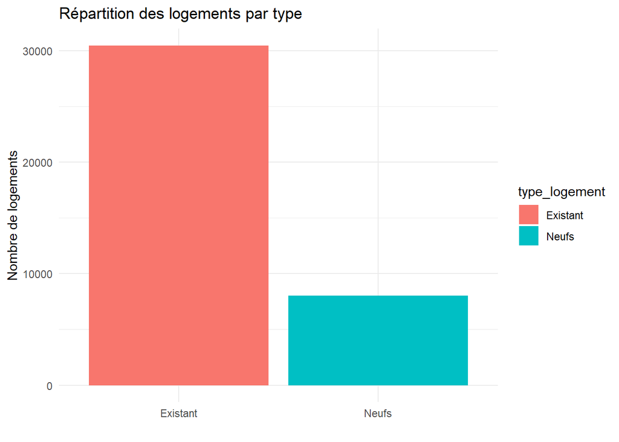

On observe une plus grosse part de logements Existants que de neufs

### Comparaison des étiquettes DPE en fonction du logement (neuf ou existant)

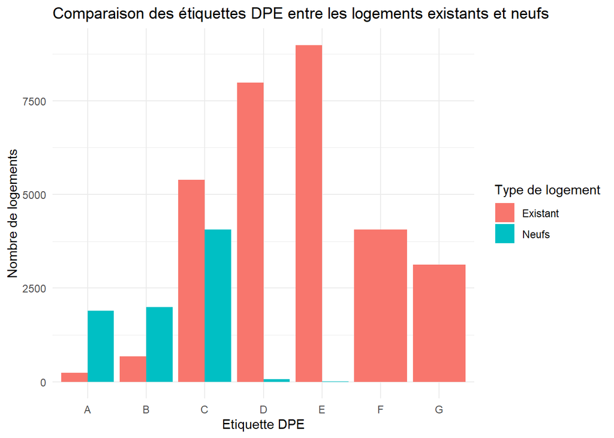

On remarque que les logements neufs sont plus souvent d’une bonne DPE par rapport aux logements anciens

### Distribution des étiquettes DPE

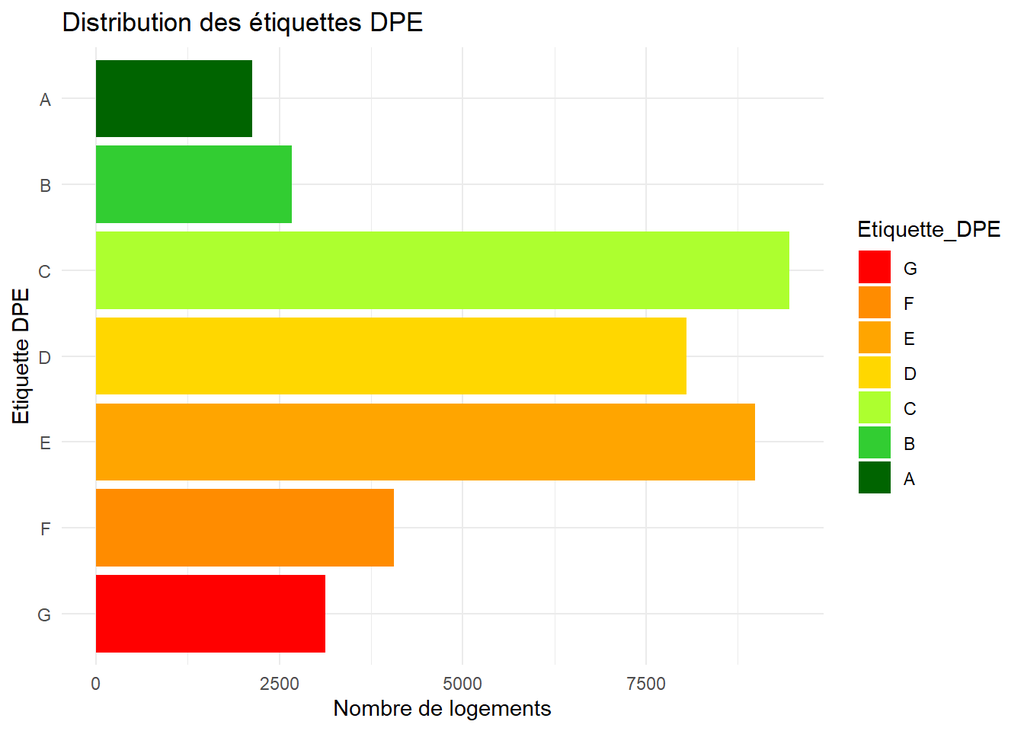

On remarque que les étiquettes des logements tournent autour de C, D et E

### Calcul de la corrélation entre l’année de construction et l’étiquette DPE

```
## [1] -0.2760801
```

La corrélation est négative, on en déduit donc que plus un bâtiment est récent, plus son étiquette DPE tend à être meilleure.

Avec une valeur aussi faible cela signifie que la date de construction n’est pas ce qui influe le plus sur l’étiquette de DPE. Les matériaux utilisé avant ne sont pas tellement différents d’aujourd’hui.

### Répartition des types d’installation de chauffage

```
## # A tibble: 4 × 3
##   Type_installation_chauffage  count percentage
##   <chr>                        <int>      <dbl>
## 1 individuel                   16574       43.1
## 2 collectif                     9685       25.2
## 3 <NA>                          7037       18.3
## 4 mixte (collectif-individuel)  5180       13.5
```

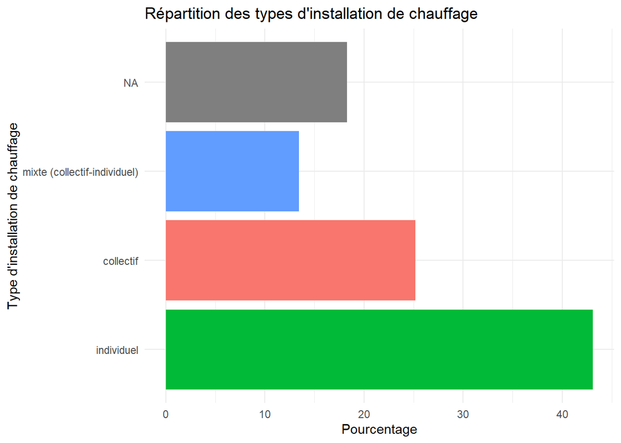

### Corrélation entre le type de chauffage et l’étiquette DPE

```
## Corrélation entre le type de chauffage et l'étiquette DPE : 0.159512
```

Cette corrélation reste assez faible donc on ne peut pas dire que le type d’affichage influe beacoup sur la note du DPE

### Nuage de points des répartitions par surface habitable

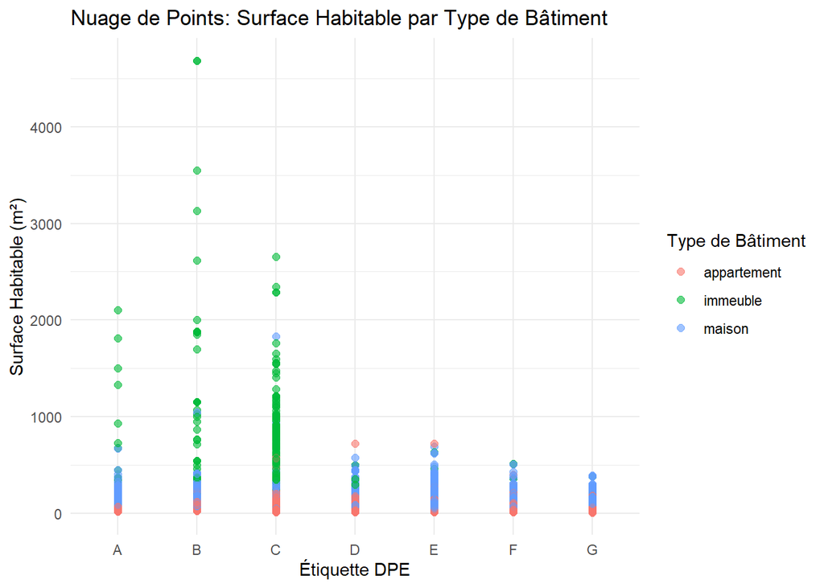

On remarque que les immeubles voir même les appartements ont plus tendance à avoir une meilleur note de DPE que les maison qui sont elles, beaucoup mieux étalé.

### Corrélation entre l’étiquette de DPE et la surface habitable

```
## [1] -0.1286927
```